# 商管程式設計（109-1）

# 作業五

## 國立臺灣大學資訊管理學系

繳交作業時，請至PDOGS（http://pdogs.ntu.im/judge/）為第一、二、三題各上傳一份 Python 3.5 原始碼（以複製貼上原始碼的方式上傳）。每位學生都要上傳自己寫的解答。不接受紙本繳交；不接受遲交。 這份作業的截止時間是2020年11月2日晚上九點。 為這份作業設計測試資料並且提供解答的助教是古佳峻。

# 第一題

(30分) 阿花在一個二維平面上畫了一條由(0, 0)到 (1, 0)的線段：

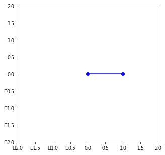

阿花覺得很多圖形都可以由這樣的線段組合而成，因此他又接著畫了(1, 0)到(1, 1)，以及(1, 1)到(0, 0)的線段：

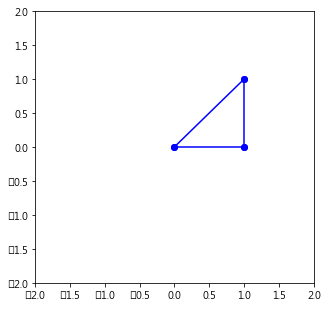

阿草看到阿花的三角形，決定幫他寫一個 Python 函數來幫阿花畫圖。首先，阿草定義一個線段是一個有四個元素的 List。比如說，由(0, 0)到 (1, 0)的線段表示為`[0, 0, 1, 0]`。也就是說，一個由(x1, y1)到(x2, y2)的線段表示為`[x1, y1, x2, y2]`。接著，阿草定義一個圖形是很多線段構成的 List，也就是 List 中包其他的 List。舉例而言，以下三個線段：

- (0, 0) 到 (1, 0)
- (1, 0) 到 (1, 1)
- (1, 1) 到 (0, 0)

可以表示成：`[[0, 0, 1, 0], [1, 0, 1, 1], [1, 1, 0, 0]]`。也就是說，我們定義了一個 List，這個 List 中共有三個 List，分別是`[0, 0, 1, 0]`、`[1, 0, 1, 1]`、`[1, 1, 0, 0]`。

這種"兩層"的 List 跟我們熟悉的，一層的 List 並沒有什麼不同。我們一樣可以用`for`迴圈的方式取用這裡面的值：

```
lil = [[0, 0, 1, 0], [1, 0, 1, 1], [1, 1, 0, 0]]
for alist in lil:
    print(alist)
```

```
[0, 0, 1, 0]
[1, 0, 1, 1]
[1, 1, 0, 0]
```

接著，阿草做了一個可以將這些線段畫出來的函數。

```
import matplotlib.pyplot as plt

def plotlines(linelist, canvas=[-2, 2, -2, 2], finalize=True):
    plt.figure(figsize=(5, 5))
    plt.axis(canvas)
    for aline in linelist:
        plt.plot([aline[0], aline[2]], [aline[1], aline[3]], linestyle='-', marker='o', color='b')
    plt.draw()
    plt.pause(.01)
    if finalize:
        plt.show()
```

將一個圖形傳入這個`plotlines`函數，就可以將圖形畫出來。例如：

```
fig1 = [[0, 0, 1, 0], [1, 0, 1, 1], [1, 1, 0, 0]]
plotlines(fig1)
```

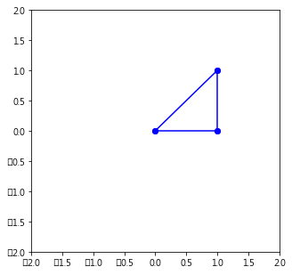

我們在這裡不討論繪圖函數的細節。這個函數主要是讓大家可以以視覺的方式看到結果。PDOGS 批改時並不會（也不能）使用這個函數。 注意這個函數用到了`matplotlib`套件，該套件在之後的章節會教到。這個套件需要自己安裝，安裝的方式是在 Terminal 內 (如cmd)下指令`pip install --user matplotlib`。詳細的安裝方式請參閱助教課影片，沒有安裝好`matplotlib`會無法執行上面的範例。

除了把圖形畫出來，另一個表示圖形的方式是把所有的線段座標印出來。小花做了`printlines`函數來完成這件事。這個函數用了一些我們還沒有詳細介紹的語法。粗略的說明，`enumerate`是可以讓 for 迴圈在使用時外加一個計數器，而`%0.3f`則是可以讓印出來的數字都只有三位小數。完成這個作業不用看懂這個函數，只要能呼叫並印出線段座標就可以。

以下是一個小型的範例：

```
def printlines(linelist):
    for i, aline in enumerate(linelist):
        print("Line%d: %0.3f %0.3f %0.3f %0.3f" % (i, aline[0], aline[1], aline[2], aline[3]))

printlines(fig1)
```

```
Line0: 0.000 0.000 1.000 0.000
Line1: 1.000 0.000 1.000 1.000
Line2: 1.000 1.000 0.000 0.000
```

由於PDOGS無法驗證`plotlines`所輸出的圖形是否正確，因此本題驗證正確性的方式為將一個圖形以`printlines`輸出，讓 PDOGS 確認這個圖形是否正確。

小草想要寫一個名叫 plotshift 的函數，這個函數可以讓圖形左右與上下平移。這個函數應該要長的像這樣：

```
def plotshift(linelist, xshift=0, yshift=0):
    # 定義你的函數

    return something
```

這個函數的傳入值 `linelist` 是一個包含所有組成圖形線段的 List，`xshift` 與 `yshift` 分別是要在 X 軸與 Y 軸平移多少單位。最後傳回一個新的圖形。

所以如果你要把 fig1 向右平移0.5單位，向下平移0.5單位，那應該這樣使用`plotshift`：

```
fig2 = plotshift(fig1, 0.5, -0.5)
plotlines(fig2)
```

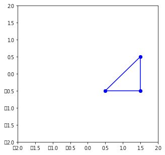

當然，我們也可以把線段的座標印出來：

```
printlines(fig2)
```

```
Line0: 0.500 -0.500 1.500 -0.500
Line1: 1.500 -0.500 1.500 0.500
Line2: 1.500 0.500 0.500 -0.500
```

請幫小草實做`plotshift`函數。你的程式大致上應該做下面的工作：

1. 讀入線段與位移
2. 呼叫`plotshift`
3. 利用`printlines`輸出結果

PDOGS將會依照`printlines`的結果確認平移的正確性。

## 輸入輸出格式

系統將會提供測試圖形與平移量。你的程式應該在取得這些資料後呼叫`plotshift`，取得平移後的圖形，並用`printlines`將結果輸出。

系統提供圖形時，所有座標值與位移量都應在$[-2, 2]$中（介於-2與2之間，包含端點）。每個圖形最少有一條線，最多的線條數量沒有限制。但測資中一個圖形不會超過100條線。第一行輸入代表第一條線，第二行輸入代表第二條線，依此類推，每行輸入皆為四個實數，以逗點分隔，前兩個數字代表線段起點的 X軸與Y軸座標，後兩個數字代表線段終點的 X 軸與 Y 軸座標。如果一行的輸入為「LINESTOP」，則代表所有的線段已經輸入完畢，下一行依序是 X 軸與 Y 軸的位移量（以逗點分隔）。

舉例而言，如果輸入是：

```
0,0,1,0
1,0,1,1
1,1,0,0
LINESTOP
0.5,-0.5
```

那輸出是：

```
Line0: 0.500 -0.500 1.500 -0.500
Line1: 1.500 -0.500 1.500 0.500
Line2: 1.500 0.500 0.500 -0.500
```

如果輸入是：

```
0.1,1.5,0,0.5
0,0.5,1,0.5
0.5,1.5,0.5,0
LINESTOP
-0.6,-0.6
```

那輸出是：

```
Line0: -0.500 0.900 -0.600 -0.100
Line1: -0.600 -0.100 0.400 -0.100
Line2: -0.100 0.900 -0.100 -0.600
```

如果輸入是：

```
-2,-2,0,0
-2,0,0,-2
LINESTOP
1.2,1.6
```

那輸出是：

```
Line0: -0.800 -0.400 1.200 1.600
Line1: -0.800 1.600 1.200 -0.400
```

## 你上傳的原始碼裡應該包含什麼

你的.py 原始碼檔案裡面應該包含讀取測試資料、做運算，以及輸出答案的Python 3.5 程式碼。當然，你應該寫適當的註解。針對這個題目，你**可以**使用上課沒有教過的方法。上傳至PDOGS的程式碼中不能包含`matplotlib`相關的程式碼，**且不能import任何套件**。

## 評分原則

這一題的所有分數都根據程式運算的正確性給分。PDOGS 會直譯並執行你的程式、輸入測試資料，並檢查輸出的答案的正確性。本題共有15 組測試資料，一筆測試資料佔2分。

# 第二題

(30分) 接續上一題的設定，阿花想要旋轉圖形。阿草去翻了以前的課本之後發現了如果要逆時鐘旋轉一個$(x_1, y_1)$的點$\theta$弧度，應該要這樣做:

$$ \begin{bmatrix} x_2 \\ y_2 \end{bmatrix} = \begin{bmatrix} \cos{\theta} & -\sin{\theta}\\ \sin{\theta} & \cos{\theta} \end{bmatrix} \begin{bmatrix} x_1\\ y_1 \end{bmatrix} $$

以上的計算拆解開來後會是這樣 : $$ x_2 = x_1*\cos{\theta} + y_1*(-\sin{\theta})\\ y_2 = x_1*\sin{\theta} + y_1*\cos{\theta} $$

於是阿花定義了旋轉函數`rotate`:

```
def rotate(linelist, degree=90):
    # 實做你的函數

    return 新圖形
```

這個函數的傳入值 `linelist` 是一個包含所有組成圖形線段的 List。`degree`為（對原點）逆時鐘旋轉的角度，轉一圈是360度。注意三角函數的輸入是弧度，轉一圈是$2\pi$。這個`rotate`函數應該要將所有`linelist`中的點逆時鐘旋轉`degree`度後，將新的圖形傳回。

舉例而言，我們看看下面這個`figq2`：

```
figq2 = [[0, 0, 1, 0], [1, 0, 1, 0.5], [1, 1, 0, 0]]
plotlines(figq2)
```

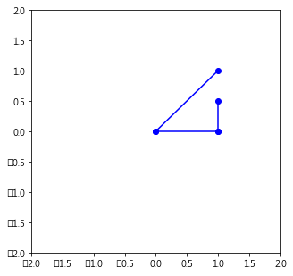

如果`rotate`函數寫好了，那我們可以呼叫這個函數，將`figq2`逆時鐘旋轉30度。這時圖形會變成：

```
figq2_1 = rotate(figq2, degree=30)
plotlines(figq2_1)
```

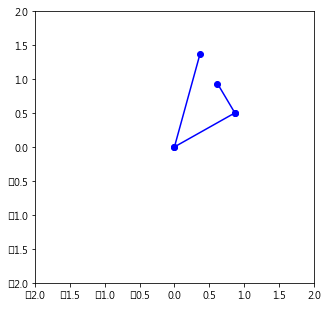

把圖形印出來：

```
printlines(figq2_1)
```

```
Line0: 0.000 0.000 0.866 0.500
Line1: 0.866 0.500 0.616 0.933
Line2: 0.366 1.366 0.000 0.000
```

如果我們逆時鐘旋轉60度，會變成：

```
figq2_2 = rotate(figq2,degree=60)
plotlines(figq2_2)
```

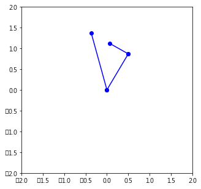

這時線段的座標是：

```
printlines(figq2_2)
```

```
Line0: 0.000 0.000 0.500 0.866
Line1: 0.500 0.866 0.067 1.116
Line2: -0.366 1.366 0.000 0.000
```

請幫小草實做`rotate`函數。你的程式大致上應該做下面的工作：

1. 讀入線段與位移
2. 呼叫`rotate`
3. 利用`printlines`輸出結果

PDOGS將會依照`printlines`的結果確認旋轉的正確性。

## 輸入輸出格式

系統將會提供測試圖形與旋轉角度。你的程式應該在取得這些資料後呼叫`rotate`，取得旋轉後的圖形，並用`printlines`將結果輸出。

系統提供圖形時，所有座標值與位移量都應在$[-2, 2]$中（介於-2與2之間，包含端點）。每個圖形最少有一條線，最多的線條數量沒有限制。但測資中一個圖形不會超過100條線。第一行輸入代表第一條線，第二行輸入代表第二條線，依此類推，每行輸入皆為四個實數，以逗點分隔，前兩個數字代表線段起點的X軸與Y軸座標，後兩個數字代表線段終點的X軸與Y軸座標。如果一行的輸入為「LINESTOP」，則代表所有的線段已經輸入完畢，下一行是旋轉角度。旋轉角度在$[-1000, 1000]$中。

舉例而言，如果輸入是：

```
0,0,1,0
1,0,1,0.5
1,1,0,0
LINESTOP
30
```

那輸出是：

```
Line0: 0.000 0.000 0.866 0.500
Line1: 0.866 0.500 0.616 0.933
Line2: 0.366 1.366 0.000 0.000
```

如果輸入是：

```
0,0,1,0
1,0,1,0.5
1,1,0,0
LINESTOP
-30
```

那輸出是：

```
Line0: 0.000 0.000 0.866 -0.500
Line1: 0.866 -0.500 1.116 -0.067
Line2: 1.366 0.366 0.000 0.000
```

## 你上傳的原始碼裡應該包含什麼

你的.py 原始碼檔案裡面應該包含讀取測試資料、做運算，以及輸出答案的Python 3.5 程式碼。當然，你應該寫適當的註解。針對這個題目，你**可以**使用上課沒有教過的方法。上傳至PDOGS的程式碼中不能包含`matplotlib`相關的程式碼，**除了`math`之外不能import其他套件**。

## 評分原則

- 這一題的其中30分會根據程式運算的正確性給分。PDOGS 會直譯並執行你的程式、輸入測試資料，並檢查輸出的答案的正確性。本題共有15 組測試資料，一筆測試資料佔2分。

# 第三題

(40分) 身為一位不專業球迷，你想要了解目前職業棒球各球隊以及個別球員的表現，希望能設計一個系統對球員的打擊成績紀錄作分析，以了解目前各球隊或是某球員的表現。 每一筆打擊成績紀錄 $R_i$ 中會記錄各個球員的隊伍代號 $T_i$、球員號碼 $N_{i}$(**不會**出現不同隊伍中的球員有相同號碼的情形)、賽季 $S_i$、打數 $AB_{i}$、安打數 $H_i$。 系統可能的分析項目共有 4 項，這幾個項目都跟打擊率有關， 打擊率的計算公式為:

$$ \frac{安打數}{打數} = \frac{H_i}{AB_i} $$

我們看看下面這個紀錄表格:

| 隊伍代號 | 球員號碼 | 賽季 | 打數 | 安打數 |
| --- | --- | --- | --- | --- |
| A | 7 | 2015 | 10 | 2 |
| D | 80 | 2015 | 10 | 2 |
| B | 14 | 2014 | 30 | 5 |
| B | 14 | 2015 | 10 | 3 |
| B | 36 | 2015 | 25 | 7 |
| E | 6 | 2016 | 20 | 1 |
| C | 22 | 2015 | 20 | 3 |
| C | 22 | 2016 | 11 | 2 |

我們可以用一個二維List `records`表示:

```
records = [["A", 7, 2015, 10, 2],
           ["D", 80, 2015, 10, 2],
           ["B", 14, 2014, 30, 5],
           ["B", 14, 2015, 10, 3],
           ["B", 36, 2015, 25, 7],
           ["E", 6, 2016, 20, 1],
           ["C", 22, 2015, 20, 3],
           ["C", 22, 2016, 11, 2]]
```

若要計算 $7$ 號球員在 $2015$ 球季的打擊率，計算公式則是: $$\frac{2}{10} = 0.2$$

若要計算同一位球員在多個賽季的打擊率，計算方式則是將指定球季的累加安打數，除以指定球季的累加打數。 舉例而言，若要計算$22$ 號球員 $2015、2016$ 球季的打擊率 (計算出的結果無條件捨去到小數點第二位)，計算公式則是:

$$\frac{3+2}{20+11} \approx 0.16$$

若要計算球隊的團隊打擊率，計算方式則是將所有屬於該球隊的球員的累加安打數，除以所有屬於該球隊的球員的累加打數。 舉例而言，若要計算 $B$ 隊在 $2015$ 球季的團隊打擊率(計算出的結果無條件捨去到小數點第二位)，計算公式則是:

$$\frac{3+7}{10+25} \approx 0.28$$

若要計算球隊在多個賽季的團隊打擊率，計算方式則是將所有屬於該球隊的球員在指定球季的累加安打數，除以所有屬於該球隊的球員在指定球季的累加打數。 舉例而言，若要計算 $B$ 隊在 $2014,2015$ 球季的團隊打擊率(計算出的結果無條件捨去到小數點第二位)，計算公式則是:

$$\frac{5+3+7}{30+10+25} \approx 0.23$$

請將每一個項目都寫成一個函數，也就是說，你的程式中至少應定義 4 個函數， 針對每一個函數，都必須依照下方指定的名稱命名，且所有函數都必須傳入指定的參數。各函數的傳入參數、具體目標與回傳值條列如下：

$(1).$ player_avg(): 計算指定球員在指定球季(一個或多個)的打擊率，計算方式則是將指定球員在指定球季的累加安打數，除以指定球季的累加打數，回傳值為一個數值。

```
def player_avg(seasons, records, player_number):
    # 實做你的函數

    return 打擊率
```

此函數需要輸入的`seasons`是指定的球季，是以 List 的形式傳入。`records`為系統中的所有紀錄，是以 List 的形式傳入。`player_number`是指定的一個球員號碼。這個`player_avg`函數應該要計算指定的`player_number`球員在`seasons`的打擊率，最後將打擊率回傳。

$(2).$ team_avg(): 計算指定球隊在指定球季的團隊打擊率，計算方式則是將所有屬於該球隊的球員的累加安打數，除以所有屬於該球隊的球員的累加打數，回傳值為一個數值。

```
def team_avg(seasons, records, team_name):
    # 實做你的函數

    return 團隊打擊率
```

此函數需要輸入的`seasons`是指定的球季，是以 List 的形式傳入。`records`為系統中的所有紀錄，是以 List 的形式傳入。`team_name`是指定的一個球隊代號。這個`team_avg`函數應該要計算指定的`team_name`在`seasons`的團隊打擊率，最後將團隊打擊率回傳。

$(3).$ best_player(): 計算各個指定球季中，所有球員的打擊率，並找出各個指定球季打擊率最高的球員，回傳值為一個 List。  
注意這裡回傳的值雖然是一個 List，不過我們最後要印出的內容將會是 List 內的所有 element，每個 element 之間用半形逗點相隔。

```
def best_player(seasons, records):
    # 實做你的函數

    return 球員號碼List
```

此函數需要輸入的`seasons`是指定的球季，是以 List 的形式傳入。`records`為系統中的所有紀錄，是以 List 的形式傳入。這個`best_player`函數應該要計算指定的`seasons`中，哪位球員有最高的打擊率，最後回傳依照`seasons`順序排列的表現最佳球員號碼，如果多名球員在某一季的打擊率相同，則選擇打數較少的那位球員， 若打數仍然相同，則選擇號碼數字較小的那位球員。

$(4).$ best_team(): 計算各個指定球季中，所有球隊的團隊打擊率，並找出各個指定球季團隊打擊率最高的球隊，回傳值為一個 List。  
注意這裡回傳的值雖然是一個 List，不過我們最後要印出的內容將會是 List 內的所有 element，每個 element 之間用半形逗點相隔。

```
def best_team(seasons, records):
    # 實做你的函數

    return 球隊代號List
```

此函數需要輸入的`seasons`是指定的球季，是以 List 的形式傳入。`records`為系統中的所有紀錄，是以 List 的形式傳入。這個`best_team`函數應該要計算指定的`seasons`中，哪支球隊有最高的團隊打擊率，最後回傳依照`seasons`順序排列的表現最佳球隊代號，如果多個球隊在某一季的團隊打擊率相同，則選擇打數較少的那個球隊，若打數仍然相同，則選擇英文字母排序較前 ($A$ 最前，$Z$ 最後)的那個球隊。

以下舉幾個例子示範前述的 $4$ 個函數的參數以及輸出。  
以前面的 `records`作為輸入

```
records = [["A", 7, 2015, 10, 2],
           ["D", 80, 2015, 10, 2],
           ["B", 14, 2014, 30, 5],
           ["B", 14, 2015, 10, 3],
           ["B", 36, 2015, 25, 7],
           ["E", 6, 2016, 20, 1],
           ["C", 22, 2015, 20, 3],
           ["C", 22, 2016, 11, 2]]
```

1. 我們想要從`records`中計算號碼為 $22$ 號的球員在$2015、2016$ 這兩個球季的打擊率，詳細的計算過程如下:  
   ( $22$ 號球員 $2015、2016$ 這兩個球季的累加安打數 ) 除以 ( $22$ 號球員 $2015、2016$ 這兩個球季的累加打數 )

$$\frac{3+2}{20+11} \approx 0.16$$

如果`player_avg`函數寫好了，那我們可以呼叫這個函數，計算該名球員在這兩個球季的打擊率。

```
player_avg(seasons=[2015, 2016], records=records, player_number=22)
```

若程式撰寫正確，則回傳值會是 $0.16$

$$\frac{5+3+7}{30+10+25} \approx 0.23$$

如果`team_avg`函數寫好了，那我們可以呼叫這個函數，計算該球隊在這兩個球季的團隊打擊率。

```
team_avg(seasons=[2014, 2015], records=records, team_name="B")
```

若程式撰寫正確，則回傳值會是 $0.23$

1. 我們想要從`records`中分別找出在$2014、2016$ 這兩個球季打擊率最高的球員，詳細的計算過程如下:

   $(1)$. 計算`records`中 $2014$ 球季中所有球員的打擊率，$2014$ 球季中只有一筆 $14$ 號球員的紀錄，按照公式計算出該名球員的打擊率是 $0.16$，由於$2014$ 球季只有該名球員的紀錄，因此$2014$ 球季打擊率最高的球員就是 $14$ 號球員。

   $(2)$. 計算`records`中 $2016$ 球季中所有球員的打擊率，$2016$ 球季中共有兩筆紀錄，分別為 $6$ 號球員以及 $22$ 號球員，分別計算出兩名球員的打擊率， $6$ 號球員為 $0.05$， $22$ 號球員為 $0.18$， $22$ 號球員有較高的打擊率，因此$2016$ 球季打擊率最高的球員就是 $22$ 號球員。

如果`best_player`函數寫好了，那我們可以呼叫這個函數，找出在這兩個球季打擊率最高的兩名球員的號碼。

```
best_player(seasons=[2014, 2016], records=records)
```

若程式撰寫正確，則回傳值會是 $[14, 22]$

1. 我們想要從`records`中分別找出在$2015、2016$ 這兩個球季團隊打擊率最高的球隊，詳細的計算過程如下:

   $(1)$. 計算`records`中 $2015$ 球季中所有球隊的團隊打擊率，按照公式計算出 $A$ 隊 $2015$ 球季的團隊打擊率是 $0.2$，$B$ 隊 $2015$ 球季的團隊打擊率是 $0.28$，$C$ 隊 $2015$ 球季的團隊打擊率是 $0.15$，$D$ 隊 $2015$ 球季的團隊打擊率是 $0.2$，因此 $2015$ 球季團隊打擊率最高的球隊就是 $B$ 隊。

   $(2)$. 計算`records`中 $2016$ 球季中所有球隊的團隊打擊率，按照公式計算出 $C$ 隊 $2016$ 球季的團隊打擊率是 $0.18$，$E$ 隊 $2016$ 球季的團隊打擊率是 $0.05$，因此 $2016$ 球季團隊打擊率最高的球隊就是 $C$ 隊。

如果`best_team`函數寫好了，那我們可以呼叫這個函數，找出在這兩個球季團隊打擊率最高的兩個球隊代號。

```
best_team(seasons=[2015, 2016], records=records)
```

若程式撰寫正確，則回傳值會是 $["B", "C"]$

最後將會指定本次分析要進行的項目以及所需要的參數，請根據所要求的項目及參數輸出相對應的結果。 請注意，若沒有完整撰寫上述 4 個函數並合理使用（也就是程式中任何你定義出的函數都應該在某個地方被呼叫到），則將無法獲得本題分數。

## 輸入輸出格式

系統會提供一共 20 組測試資料，每組測試資料裝在一個檔案裡。

系統提供紀錄時，每一行包含一個字串以及四個整數，依序為球隊代號$T_i$、球員號碼$N_{i}$、賽季$S_i$、打數$AB_{i}$、安打數$H_i$，以逗點分隔。  
第一行輸入代表第一筆紀錄，第二行輸入代表第二筆紀錄，依此類推。如果一行的輸入為「RECORDSTOP」，則代表所有的紀錄已經輸入完畢，接下來的每一行是要進行的項目，每一筆測資中可能會要進行**多個**項目，且各個項目可能會重複出現，直到一行的輸入為「FUNCTIONSTOP」，則代表所有要進行的項目已經輸入完畢。 項目的輸入分成幾個選項，

- 若要進行的項目為**計算球員打擊率**則輸入包含三個部分，第一個部分是正整數 $1$；第二個部分是一串正整數，是要分析的球季，以逗號分隔；第三個部分是一個正整數，是要計算打擊率的球員號碼，這三個部分中間以**半形空格**隔開。
- 若要進行的項目為**計算球隊打擊率**則輸入包含三個部分，第一個部分是正整數 $2$；第二個部分是一串正整數，是要分析的球季，以逗號分隔；第三個部分是一個字串，是要計算打擊率的球隊代號，這三個部分中間以**半形空格**隔開。
- 若要進行的項目為**找出表現最佳球員**則輸入包含兩個部分，第一個部分是正整數 $3$；第二個部分是一串正整數，是要分析的球季，以逗號分隔，這兩個部分中間以**半形空格**隔開。
- 若要進行的項目為**找出表現最佳球隊**則輸入包含兩個部分，第一個部分是正整數 $4$；第二個部分是一串正整數，是要分析的球季，以逗號分隔，這兩個部分中間以**半形空格**隔開。

輸出時，依照項目的讀入順序輸出即可，每一個項目的輸出各自佔一行，若分析結果包含多個數字，則各數字之間以`半形逗號`隔開。若數字有小數點，則無條件捨去至小數點第二位再印出（印出時再無條件捨去即可，運算過程中不要） 所有測資中，**不會**出現不同隊伍中的球員有相同號碼的情形。  
如果多名球員在某一季的打擊率相同，則選擇打數**較少**的那位球員，若打數仍然相同，則選擇號碼數字**較小**的那位球員。  
如果出現多個球隊在某一季的團隊打擊率相同的情形，則選擇打數**較少**的那個球隊，若打數仍然相同，則選擇英文字母排序**較前** ($A$ 最前，$Z$ 最後)的那個球隊。  
計算打擊率時，請依照題目所敘述的公式進行計算，並無條件捨去到小數點第二位。另外請注意，若打擊率經過無條件捨去到小數點第二位後，小數點後的尾數為零，請不要印出，例如若計算出的打擊率為 $0.503$，經過無條件捨去到小數點第二位後計算出 $0.50$，這時請印出 $0.5$，而不是印出 $0.50$ ；或是計算出的打擊率為 $0.006$，經過無條件捨去到小數點第二位後計算出 $0.00$，這時請印出 $0$，而不是印出 $0.00$，否則會被 PDGOS 判定為錯誤。  
這裡提供一個計算無條件捨去到小數點第二位時的 function : 將計算出的結果傳入，回傳值即為符合本次輸出要求的格式。

```
def chop(avg):
    avg = int(avg*100) / 100
    return avg if avg > 0 else 0
```

已知 $T_i$ 為任意大寫英文字母、$1\leq$ $N_{i}$ $\leq100$、$1990\leq$ $S_i$ $\leq2020$、$1\leq$ $AB_{i}$ $\leq1000$、$0\leq$ $H_i$ $\leq1000$。  
舉例而言，如果輸入是：

```
A,7,2013,15,7
F,25,2013,10,3
B,11,2013,25,6
B,35,2013,30,2
C,17,2014,17,9
A,7,2014,10,5
A,22,2014,17,3
RECORDSTOP
1 2013,2014 7
3 2014
FUNCTIONSTOP
```

那輸出是：

```
0.48
17
```

如果輸入是：

```
A,7,2013,15,7
F,25,2015,10,3
B,11,2015,25,6
B,35,2013,30,2
C,17,2016,17,9
A,22,2016,17,3
RECORDSTOP
4 2015,2016
2 2013,2016 A
2 2015 B
FUNCTIONSTOP
```

那輸出是：

```
F,C
0.31
0.24
```

## 你上傳的原始碼裡應該包含什麼

你的.py 原始碼檔案裡面應該包含讀取測試資料、做運算，以及輸出答案的Python 3.5 程式碼。當然，你應該寫適當的註解。針對這個題目，你**可以**使用上課沒有教過的方法。上傳至PDOGS的程式碼中**不能import任何套件**。